# MUSA 5080 Midterm

Single-Family Home Price Prediction in Philadelphia

Author

Jed Chew

Published

December 7, 2025

## MUSA 5080 Midterm

**Goal:** Predict 2023-2024 home sale prices accurately while communicating findings clearly to a policy audience.

## Part 1: Data Cleaning & Preparation

### Primary Dataset: [Property Sales](https://metadata.phila.gov/#home/datasetdetails/5543865f20583086178c4ee5/representationdetails/55d624fdad35c7e854cb21a4/)

This dataset contains actual property sales with:

- Sale price
- Sale date
- Property characteristics (bedrooms, bathrooms, sq ft, etc.)
- Property location (address, coordinates)

### Step 1: Load and clean Philadelphia sales data

- Clean it (missing values, outliers, data errors)
- Filter to 2023-2024 residential sales only

```r
sales_data <- read_csv("data/clean_data.csv")
head(sales_data)
```

```
# A tibble: 6 × 51
  sale_date           sale_price total_area total_livable_area year_built
  <dttm>                   <dbl>      <dbl>              <dbl>      <dbl>
1 2024-04-16 08:00:00      90000        644                900       1925
2 2024-10-18 08:00:00      20000       1073                976       1940
3 2023-09-17 08:00:00     389000       4701               1080       1961
4 2023-08-01 08:00:00     309000       2050               1792       1925
5 2023-07-31 08:00:00     185000       1125               1440       1925
6 2024-06-30 08:00:00     399000       1984               2292       1925
# ℹ 46 more variables: category_code <dbl>, category_code_description <chr>,
#   census_tract <dbl>, exterior_condition <dbl>, interior_condition <dbl>,
#   fireplaces <dbl>, garage_spaces <dbl>, general_construction <chr>,
#   market_value <dbl>, number_of_bathrooms <dbl>, number_of_bedrooms <dbl>,
#   basements <chr>, prop_id <dbl>, violent_2blocks <dbl>, petty_1block <dbl>,
#   neigh_name <chr>, dist_stop_ft <dbl>, dist_bike_ft <dbl>,
#   dist_hosp_mi <dbl>, service_band_code <dbl>, service_band <chr>, …
```

```r
glimpse(sales_data)
```

```
Rows: 19,736
Columns: 51
$ sale_date                 <dttm> 2024-04-16 08:00:00, 2024-10-18 08:00:00, 2…
$ sale_price                <dbl> 90000, 20000, 389000, 309000, 185000, 399000…
$ total_area                <dbl> 644, 1073, 4701, 2050, 1125, 1984, 1384, 111…
$ total_livable_area        <dbl> 900, 976, 1080, 1792, 1440, 2292, 1188, 1845…
$ year_built                <dbl> 1925, 1940, 1961, 1925, 1925, 1925, 1950, 19…
$ category_code             <dbl> 1, 1, 1, 1, 1, 1, 1, 1, 1, 1, 1, 1, 1, 1, 1,…
$ category_code_description <chr> "SINGLE FAMILY", "SINGLE FAMILY", "SINGLE FA…
$ census_tract              <dbl> 41, 287, 356, 184, 191, 158, 313, 356, 255, …
$ exterior_condition        <dbl> 5, 6, 4, 4, 4, 4, 4, 3, 4, 4, 4, 3, 4, 6, 4,…
$ interior_condition        <dbl> 5, 5, 4, 4, 4, 4, 4, 3, 3, 2, 2, 4, 3, 5, 4,…
$ fireplaces                <dbl> 0, 0, 0, 0, 0, 0, 0, 1, 0, 0, 0, 0, 0, 0, 0,…
$ garage_spaces             <dbl> 0, 0, 1, 0, 1, 1, 1, 0, 0, 0, 0, 0, 0, 0, 1,…
$ general_construction      <chr> "A", "A", "A", "A", "A", "A", "A", "A", "A",…
```

[output cut: 38 more lines]

### Step 2: Load Secondary Data

- Census data (tidycensus):
- Spatial amenities (OpenDataPhilly)
- Join to sales data appropriately
- Make sure you have the correct CRS!

### Step 3: Feature Engineering

1. **Buffer-based features**:
   - Parks within 500ft, 1000ft
   - Transit stops within 400ft
   - Schools, crime, etc.
2. **k-Nearest Neighbor features**:
   - Average distance to k nearest parks, transit, etc.
3. **Census variables**:
   - Join median income, education, poverty, etc.
4. **Interaction terms**:
   - Theoretically motivated combinations

### Step 4: Exploratory Data Analysis

**Create at least 5 professional visualizations:**

1. Distribution of sale prices (histogram)
2. Geographic distribution (map)
3. Price vs. structural features (scatter plots)
4. Price vs. spatial features (scatter plots)
5. One creative visualization

```r
# Create New Columns for Further Cleaning
sales_data <- sales_data |>
  mutate(psf = round(sale_price / total_livable_area, 2),
         value_multiple = round(market_value / sale_price, 2)) |>
  arrange(psf)
sales_data
```

```
# A tibble: 19,736 × 53
   sale_date           sale_price total_area total_livable_area year_built
   <dttm>                   <dbl>      <dbl>              <dbl>      <dbl>
 1 2024-03-11 08:00:00      10000      14895               4200       1900
 2 2024-02-22 10:00:00      12000       1150               2400       2014
 3 2024-03-15 08:00:00      10000       1575               1656       1940
 4 2023-09-06 08:00:00      15000       1201               2451       1915
 5 2023-10-17 08:00:00      10000       1700               1516       1935
 6 2024-08-06 08:00:00      14500        946               1892       1915
 7 2023-11-17 10:00:00      10000        923               1260       1920
 8 2023-01-17 10:00:00      10000       1410               1260       1940
 9 2023-07-27 08:00:00      10000        821               1189       1925
10 2023-07-07 08:00:00      11000       1156               1290       1940
# ℹ 19,726 more rows
# ℹ 48 more variables: category_code <dbl>, category_code_description <chr>,
#   census_tract <dbl>, exterior_condition <dbl>, interior_condition <dbl>,
#   fireplaces <dbl>, garage_spaces <dbl>, general_construction <chr>,
#   market_value <dbl>, number_of_bathrooms <dbl>, number_of_bedrooms <dbl>,
#   basements <chr>, prop_id <dbl>, violent_2blocks <dbl>, petty_1block <dbl>,
#   neigh_name <chr>, dist_stop_ft <dbl>, dist_bike_ft <dbl>, …
```

```r
colnames(sales_data)
```

```
 [1] "sale_date"                 "sale_price"
 [3] "total_area"                "total_livable_area"
 [5] "year_built"                "category_code"
 [7] "category_code_description" "census_tract"
 [9] "exterior_condition"        "interior_condition"
[11] "fireplaces"                "garage_spaces"
[13] "general_construction"      "market_value"
[15] "number_of_bathrooms"       "number_of_bedrooms"
[17] "basements"                 "prop_id"
[19] "violent_2blocks"           "petty_1block"
[21] "neigh_name"                "dist_stop_ft"
[23] "dist_bike_ft"              "dist_hosp_mi"
[25] "service_band_code"         "service_band"
[27] "dist_park_ft"              "dist_park_mi"
[29] "dist_school_public_ft"     "dist_school_charter_ft"
[31] "dist_school_private_ft"    "dist_foodretail_ft"
[33] "foodretail_1mi_count"      "dist_police_ft"
[35] "dist_fire_ft"              "lu2_code"
[37] "GEOID"                     "pct_white"
[39] "pct_black"                 "pct_hispanic"
[41] "pct_asian"                 "pct_age_25_44"
[43] "pct_age_45_64"             "pct_age_65plus"
[45] "vacancy_rate"              "med_gross_rent"
[47] "med_hh_income"             "poverty_rate"
[49] "pct_ba_plus"               "pct_hs_only"
[51] "unemployment_rate"         "psf"
[53] "value_multiple"
```

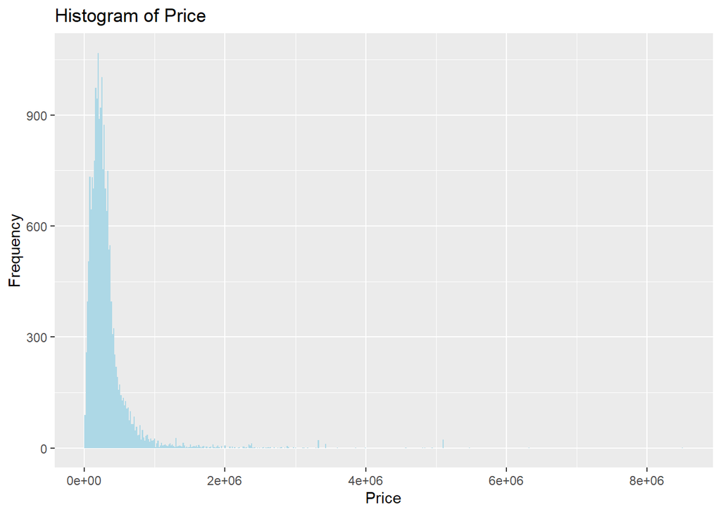

```r
# Histogram of Price
ggplot(sales_data, aes(x = sale_price)) +
  geom_histogram(fill = "lightblue", bins= 500) +
  labs(title = "Histogram of Price", x = "Price", y = "Frequency")
```

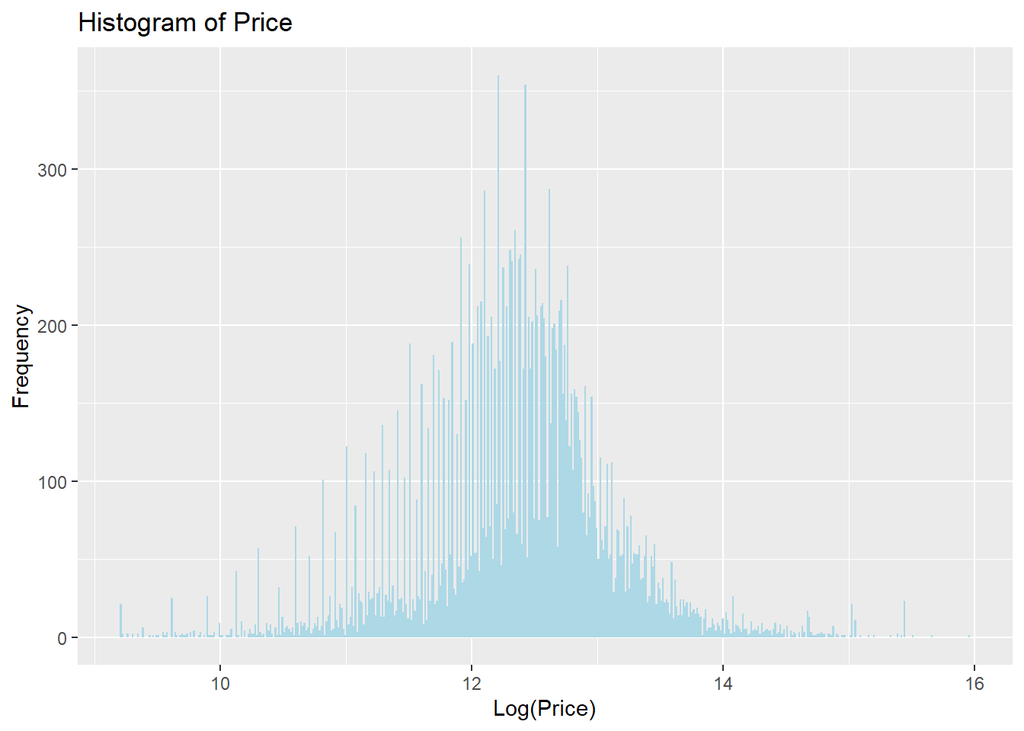

```r
# Log Sales Price
log_sales_data <- mutate(sales_data, log_price = log(sale_price))
ggplot(log_sales_data, aes(x = log_price)) +
  geom_histogram(fill = "lightblue", bins= 500) +
  labs(title = "Histogram of Price", x = "Log(Price)", y = "Frequency")
```

```r
# Further Cleaning
select_data <- sales_data |>
  select(year_built, number_of_bathrooms, number_of_bedrooms, basements,
         fireplaces, garage_spaces,
         general_construction, interior_condition, exterior_condition,
         census_tract, neigh_name,
         value_multiple, market_value, sale_price, total_area, total_livable_area,
         psf, violent_2blocks, petty_1block, dist_park_mi,
         vacancy_rate, med_gross_rent, med_hh_income, pct_ba_plus,
         pct_white, pct_black, pct_hispanic, pct_asian,
         foodretail_1mi_count,
         dist_school_public_ft, dist_school_charter_ft,
         pct_age_25_44, pct_age_65plus,
         poverty_rate, unemployment_rate) |>
  filter(number_of_bathrooms > 0, number_of_bedrooms > 0) |>
  mutate(age = 2024 - year_built,
         basements = dplyr::recode(trimws(as.character(basements)),
                              "0"="0","A"="1","B"="2","C"="3","D"="4","E"="5",
                              "F"="6","G"="7","H"="8","I"="9"),
         basements = as.integer(basements)) |>
  rename(
    baths      = number_of_bathrooms,
    beds       = number_of_bedrooms,
    construction = general_construction,
    interior   = interior_condition,
    exterior   = exterior_condition,
    garage     = garage_spaces,
    tract      = census_tract,
    neigh      = neigh_name,
    mkt_value  = market_value,
    area       = total_area,
    liv_area   = total_livable_area
  )

# Intuition: market value should not deviate substantially
# from the sale price
value_range <- select_data |>
  summarize(
    q1 = quantile(value_multiple, 0.25, na.rm = TRUE),
    q3 = quantile(value_multiple, 0.75, na.rm = TRUE),
    iqr = q3 - q1,
    lower = q1 - 1.5 * iqr,
    upper = q3 + 1.5 * iqr)
value_range
```

```
# A tibble: 1 × 5
     q1    q3   iqr lower upper
  <dbl> <dbl> <dbl> <dbl> <dbl>
1  0.87  1.16  0.29 0.435  1.59
```

```r
# Intuition: psf outliers are likely non-market transactions
psf_range <- select_data |>
  summarize(
    q1 = quantile(psf, 0.25, na.rm = TRUE),
    q3 = quantile(psf, 0.75, na.rm = TRUE),
    iqr = q3 - q1,
    lower = q1 - 1.5 * iqr,
    upper = q3 + 1.5 * iqr)
psf_range
```

```
# A tibble: 1 × 5
     q1    q3   iqr lower upper
  <dbl> <dbl> <dbl> <dbl> <dbl>
1  132.  267.  135. -70.6  469.
```

```r
clean_data <- select_data |>
  filter(
    liv_area > 500,
    area > 500,
    between(psf, 40, 800),
    between(value_multiple, 0.4, 2.0)
  ) |>
  mutate(across(where(is.numeric), ~ round(.x, 2))) |>
  drop_na() |>
  arrange(liv_area)
clean_data
```

```
# A tibble: 17,174 × 36
   year_built baths  beds basements fireplaces garage construction interior
        <dbl> <dbl> <dbl>     <dbl>      <dbl>  <dbl> <chr>           <dbl>
 1       1920     1     1         4          0      0 A                   2
 2       1920     1     2         3          0      0 A                   4
 3       1915     1     1         4          0      0 A                   4
 4       1920     1     2         5          0      0 A                   2
 5       1920     1     2         3          0      0 A                   3
 6       1920     1     2         1          0      0 A                   2
 7       1920     1     2         1          0      0 A                   2
 8       1920     1     2         2          0      0 A                   2
 9       1875     1     2         3          0      0 A                   4
10       1875     1     2         3          0      0 A                   3
# ℹ 17,164 more rows
# ℹ 28 more variables: exterior <dbl>, tract <dbl>, neigh <chr>,
#   value_multiple <dbl>, mkt_value <dbl>, sale_price <dbl>, area <dbl>,
#   liv_area <dbl>, psf <dbl>, violent_2blocks <dbl>, petty_1block <dbl>,
#   dist_park_mi <dbl>, vacancy_rate <dbl>, med_gross_rent <dbl>,
#   med_hh_income <dbl>, pct_ba_plus <dbl>, pct_white <dbl>, pct_black <dbl>,
#   pct_hispanic <dbl>, pct_asian <dbl>, foodretail_1mi_count <dbl>, …
```

```r
# Quick Category Check
count(clean_data, neigh)
```

```
# A tibble: 144 × 2
   neigh                n
   <chr>            <int>
 1 ACADEMY_GARDENS     65
 2 ALLEGHENY_WEST     160
 3 ANDORRA             38
 4 ASTON_WOODBRIDGE    43
 5 BARTRAM_VILLAGE     14
 6 BELLA_VISTA         80
 7 BELMONT             18
 8 BLUE_BELL_HILL       5
 9 BREWERYTOWN        147
10 BRIDESBURG         114
# ℹ 134 more rows
```

```r
count(clean_data, interior)
```

```
# A tibble: 7 × 2
  interior     n
     <dbl> <int>
1        1   362
2        2  3058
3        3  3831
4        4  9774
5        5   103
6        6    24
7        7    22
```

```r
count(clean_data, exterior)
```

```
# A tibble: 7 × 2
  exterior     n
     <dbl> <int>
1        1   368
2        2   645
3        3  1833
4        4 14122
5        5   161
6        6    12
7        7    33
```

```r
count(clean_data, basements)
```

```
# A tibble: 10 × 2
   basements     n
       <dbl> <int>
 1         0   268
 2         1  3868
 3         2   814
 4         3  4234
 5         4  3046
 6         5  1706
 7         6  1810
 8         7   483
 9         8   915
10         9    30
```

**Metadata: Basements**

0. None
1. A = Full Finished
2. B = Full Semi-Finished
3. C = Full Unfinished
4. D = Full
5. E = Partial Finished
6. F = Partial Semi-Finished
7. G = Partial Unfinished
8. H = Partial - Unknown Finish
9. I = Unknown Size - Finished

### Step 5: Summary Statistics

```r
# Calculate Summary Stats
stats_df <- clean_data %>%
  summarise(across(
    where(is.numeric),
    list(
      mean   = ~ mean(.x, na.rm = TRUE),
      median = ~ median(.x, na.rm = TRUE),
      sd     = ~ sd(.x, na.rm = TRUE),
      q25    = ~ as.numeric(quantile(.x, 0.25, na.rm = TRUE)),
      q75    = ~ as.numeric(quantile(.x, 0.75, na.rm = TRUE))
    ),
    .names = "{.col}__{.fn}"
  )) %>%
  pivot_longer(everything(),
               names_to = c("variable","stat"),
               names_sep = "__",
               values_to = "value") %>%
  pivot_wider(names_from = stat, values_from = value) %>%
  mutate(across(-variable, ~ round(.x, 2))) %>%
  arrange(variable)

# Table Output
library(kableExtra)
kbl(stats_df,
    caption   = "Summary Statistics",
    col.names = c("Variable","Mean","Median","SD","Q25","Q75"),
    align     = c("l","r","r","r","r","r"),
    booktabs  = TRUE
) %>%
  kable_styling(full_width = FALSE,
                bootstrap_options = c("striped","hover","condensed")) %>%
  add_header_above(c(" " = 1, "Statistics" = 5))
```

Summary Statistics

| Variable | Statistics Mean | Statistics Median | Statistics SD | Statistics Q25 | Statistics Q75 |
| --- | --- | --- | --- | --- | --- |
| age | 87.43 | 99.00 | 28.15 | 74.00 | 104.00 |
| area | 1968.09 | 1226.00 | 4042.11 | 896.00 | 1845.75 |
| basements | 3.54 | 3.00 | 2.04 | 2.00 | 5.00 |
| baths | 1.46 | 1.00 | 0.69 | 1.00 | 2.00 |
| beds | 3.09 | 3.00 | 0.72 | 3.00 | 3.00 |
| dist_park_mi | 0.16 | 0.14 | 0.11 | 0.08 | 0.22 |
| dist_school_charter_ft | 3387.13 | 2676.00 | 2520.44 | 1704.38 | 4255.10 |
| dist_school_public_ft | 1531.73 | 1362.89 | 902.98 | 894.00 | 1945.96 |
| exterior | 3.77 | 4.00 | 0.65 | 4.00 | 4.00 |
| fireplaces | 0.07 | 0.00 | 0.35 | 0.00 | 0.00 |
| foodretail_1mi_count | 44.55 | 45.00 | 20.61 | 30.00 | 57.00 |
| garage | 0.37 | 0.00 | 0.54 | 0.00 | 1.00 |
| interior | 3.37 | 4.00 | 0.87 | 3.00 | 4.00 |
| liv_area | 1379.56 | 1224.00 | 579.84 | 1076.00 | 1500.00 |
| med_gross_rent | 1368.47 | 1320.00 | 312.66 | 1155.00 | 1561.00 |
| med_hh_income | 69281.93 | 63628.00 | 30345.38 | 46492.00 | 86222.00 |
| mkt_value | 294129.43 | 244000.00 | 228503.89 | 166725.00 | 341075.00 |
| pct_age_25_44 | 34.08 | 30.18 | 11.98 | 26.18 | 40.20 |
| pct_age_65plus | 13.76 | 12.59 | 6.78 | 8.33 | 17.38 |
| pct_asian | 7.29 | 4.58 | 8.53 | 1.08 | 10.05 |
| pct_ba_plus | 34.37 | 28.22 | 22.78 | 15.84 | 51.34 |
| pct_black | 33.57 | 20.15 | 31.87 | 6.56 | 54.57 |
| pct_hispanic | 15.51 | 8.68 | 17.81 | 4.48 | 18.80 |
| pct_white | 38.82 | 36.08 | 29.69 | 8.50 | 67.45 |
| petty_1block | 29.09 | 25.00 | 29.48 | 15.00 | 36.00 |
| poverty_rate | 19.63 | 17.26 | 12.56 | 10.30 | 26.58 |
| psf | 213.18 | 200.22 | 101.73 | 142.00 | 266.67 |
| sale_price | 304050.36 | 250000.00 | 243673.32 | 170000.00 | 359000.00 |
| tract | 200.52 | 202.00 | 118.79 | 85.00 | 314.00 |
| unemployment_rate | 8.38 | 7.19 | 5.70 | 3.89 | 11.90 |
| vacancy_rate | 8.85 | 7.84 | 5.74 | 4.77 | 11.90 |
| value_multiple | 1.01 | 0.99 | 0.26 | 0.86 | 1.12 |
| violent_2blocks | 44.85 | 35.00 | 39.37 | 17.00 | 61.00 |
| year_built | 1936.57 | 1925.00 | 28.15 | 1920.00 | 1950.00 |

**Correlation Matrix**

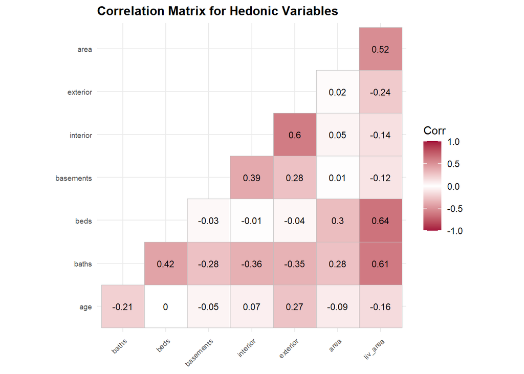

```r
hedonic_vars <- clean_data[, c("age", "baths", "beds", "basements", "interior", "exterior", "area", "liv_area")]

cor_matrix <- cor(hedonic_vars, use = "pairwise.complete.obs", method = "pearson")

ggcorrplot(cor_matrix,
           method = "square",
           type = "lower",
           lab = TRUE,
           lab_size = 3,
           colors = c("#a4133c", "white", "#a4133c"))+
    labs(title = "Correlation Matrix for Hedonic Variables") +
    theme(plot.subtitle = element_text(size = 9, face = "italic"),
        plot.title = element_text(size = 12, face = "bold"),
        axis.text.x = element_text(size = 7),
        axis.text.y = element_text(size = 7),
        axis.title = element_text(size = 8))
```

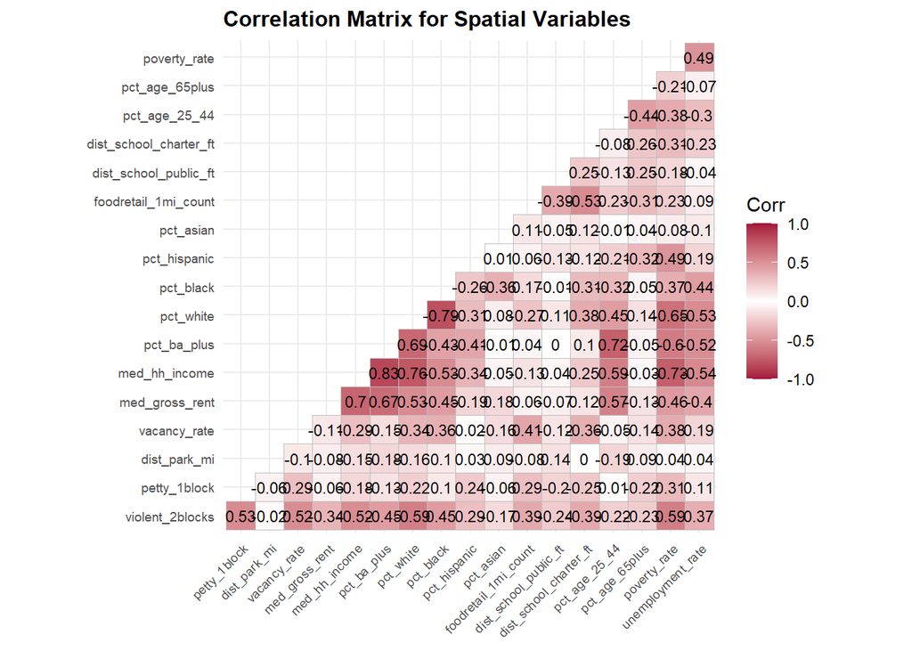

```r
spatial_vars <- clean_data[, c(
  "violent_2blocks", "petty_1block", "dist_park_mi",
  "vacancy_rate", "med_gross_rent", "med_hh_income", "pct_ba_plus",
  "pct_white", "pct_black", "pct_hispanic", "pct_asian",
  "foodretail_1mi_count",
  "dist_school_public_ft", "dist_school_charter_ft",
  "pct_age_25_44", "pct_age_65plus",
  "poverty_rate", "unemployment_rate"
)]

spatial_matrix <- cor(spatial_vars, use = "pairwise.complete.obs", method = "pearson")

ggcorrplot(spatial_matrix,
           method = "square",
           type = "lower",
           lab = TRUE,
           lab_size = 3,
           colors = c("#a4133c", "white", "#a4133c"))+
    labs(title = "Correlation Matrix for Spatial Variables") +
    theme(plot.subtitle = element_text(size = 9, face = "italic"),
        plot.title = element_text(size = 12, face = "bold"),
        axis.text.x = element_text(size = 7),
        axis.text.y = element_text(size = 7),
        axis.title = element_text(size = 8))
```

## Part 2: Model Building & Evaluation using Cross-Validation

Evaluate the model fit and predictive reliability using key metrics such as Mean Absolute Error (MAE), Root Mean Squared Error (RMSE), and R-squared.

```r
clean_data$neigh <- as.factor(clean_data$neigh)
clean_data$interior <- as.factor(clean_data$interior)
clean_data$exterior <- as.factor(clean_data$exterior)
clean_data$basements <- as.factor(clean_data$basements)

count(clean_data, neigh)
```

```
# A tibble: 144 × 2
   neigh                n
   <fct>            <int>
 1 ACADEMY_GARDENS     65
 2 ALLEGHENY_WEST     160
 3 ANDORRA             38
 4 ASTON_WOODBRIDGE    43
 5 BARTRAM_VILLAGE     14
 6 BELLA_VISTA         80
 7 BELMONT             18
 8 BLUE_BELL_HILL       5
 9 BREWERYTOWN        147
10 BRIDESBURG         114
# ℹ 134 more rows
```

```r
count(clean_data, interior)
```

```
# A tibble: 7 × 2
  interior     n
  <fct>    <int>
1 1          362
2 2         3058
3 3         3831
4 4         9774
5 5          103
6 6           24
7 7           22
```

```r
count(clean_data, exterior)
```

```
# A tibble: 7 × 2
  exterior     n
  <fct>    <int>
1 1          368
2 2          645
3 3         1833
4 4        14122
5 5          161
6 6           12
7 7           33
```

```r
count(clean_data, basements)
```

```
# A tibble: 10 × 2
   basements     n
   <fct>     <int>
 1 0           268
 2 1          3868
 3 2           814
 4 3          4234
 5 4          3046
 6 5          1706
 7 6          1810
 8 7           483
 9 8           915
10 9            30
```

```r
set.seed(5080) # Set seed for reproducibility
ctrl <- trainControl(method = "cv", number = 10) #10-Fold CV

# Model 1: Structural
cv_m1 <- train(
  sale_price ~ beds + baths + basements + interior + exterior + liv_area + poly(age, 2),
  data = clean_data, method = "lm", trControl = ctrl
)

# Model 2: + Spatial
cv_m2 <- train(
  sale_price ~ beds + baths + basements + interior + exterior + liv_area + poly(age, 2) +
  dist_park_mi + foodretail_1mi_count + dist_school_public_ft
  + vacancy_rate + med_gross_rent + med_hh_income + pct_ba_plus + pct_black + pct_white
  + poverty_rate + unemployment_rate + pct_age_25_44 + pct_age_65plus,
  data = clean_data, method = "lm", trControl = ctrl
)

# Model 3: + Neighborhood Fixed Effects
cv_m3 <- train(
  sale_price ~ beds + baths + basements + interior + exterior + liv_area + poly(age, 2) +
  dist_park_mi + foodretail_1mi_count + dist_school_public_ft +
  vacancy_rate + med_gross_rent + med_hh_income + pct_ba_plus + pct_black + pct_white +
  poverty_rate + unemployment_rate + pct_age_25_44 + pct_age_65plus +
  neigh,
  data = clean_data, method = "lm", trControl = ctrl
)

# Model 4: + Small Neighborhoods + Mkt Value
clean_data <- clean_data |>
  add_count(neigh) |>
  mutate(
    neigh_cv = if_else(
      n < 10,                       # If fewer than 10 sales
      "Small_Neighborhoods",        # Group them
      as.character(neigh)           # Keep original
    ),
    neigh_cv = as.factor(neigh_cv)
  )

cv_m4 <- train(
  sale_price ~ beds + baths + basements + interior + exterior + liv_area + poly(age, 2) +
  violent_2blocks + dist_park_mi + foodretail_1mi_count + dist_school_public_ft +
  vacancy_rate + med_gross_rent + med_hh_income + pct_ba_plus + pct_black + pct_white +
  poverty_rate + unemployment_rate + pct_age_25_44 + pct_age_65plus +
  mkt_value +
  neigh_cv,
  data = clean_data, method = "lm", trControl = ctrl
)

# Model 5: + Simpler + Mkt Value
cv_m5 <- train(
  sale_price ~ beds + baths + basements + interior + exterior + liv_area + poly(age, 2) +
  dist_park_mi + foodretail_1mi_count + dist_school_public_ft +
  mkt_value +
  neigh_cv,
  data = clean_data, method = "lm", trControl = ctrl
)

# Model 6: Simpler Only
cv_m6 <- train(
  sale_price ~ beds + baths + basements + interior + exterior + liv_area + poly(age, 2) +
  dist_park_mi + foodretail_1mi_count + dist_school_public_ft +
  neigh_cv,
  data = clean_data, method = "lm", trControl = ctrl
)

# Compare
data.frame(
  Model = c("Structural", "Spatial", "Fixed Effects", "Small Neighborhoods + Mkt Value", "Simpler + Mkt Value", "Simpler Only"),
  Rsquared = c(cv_m1$results$Rsquared, cv_m2$results$Rsquared, cv_m3$results$Rsquared,
               cv_m4$results$Rsquared, cv_m5$results$Rsquared, cv_m6$results$Rsquared),
  RMSE = c(cv_m1$results$RMSE, cv_m2$results$RMSE, cv_m3$results$RMSE,
           cv_m4$results$RMSE, cv_m5$results$RMSE, cv_m6$results$RMSE),
  MAE = c(cv_m1$results$MAE, cv_m2$results$MAE, cv_m3$results$MAE,
          cv_m4$results$MAE, cv_m5$results$MAE, cv_m6$results$MAE)
)
```

```
                            Model  Rsquared      RMSE      MAE
1                      Structural 0.6734982 139097.27 91009.99
2                         Spatial 0.7910435 111374.22 67559.44
3                   Fixed Effects 0.8489664  95369.77 56768.27
4 Small Neighborhoods + Mkt Value 0.9266800  65382.05 42496.50
5             Simpler + Mkt Value 0.9282046  65402.58 42527.28
6                    Simpler Only 0.8415987  96901.51 58377.83
```

```r
lm_model3 <- cv_m3$finalModel
vif_model3 <- vif(lm_model3)
vif_m3 <- data.frame(Variable = names(vif_model3), # convert to data frame
                     VIF = as.vector(vif_model3))
kable(vif_m3, caption = "Variance Inflation Factors for Model 3: Fixed Effects")
```

Variance Inflation Factors for Model 3: Fixed Effects

| Variable | VIF |
| --- | --- |
| beds | 2.049265 |
| baths | 2.214022 |
| basements1 | 14.301690 |
| basements2 | 4.494605 |
| basements3 | 15.741349 |
| basements4 | 12.630752 |
| basements5 | 7.769069 |
| basements6 | 8.457106 |
| basements7 | 3.162235 |
| basements8 | 4.963679 |
| basements9 | 1.148218 |
| interior2 | 433.595343 |
| interior3 | 511.190303 |
| interior4 | 725.322963 |
| interior5 | 18.775469 |
| interior6 | 5.373467 |
| interior7 | 6.004538 |
| exterior2 | 107.584125 |
| exterior3 | 280.208816 |
| exterior4 | 430.490151 |
| exterior5 | 28.543354 |
| exterior6 | 3.252689 |
| exterior7 | 7.935073 |
| liv_area | 2.840232 |
| `poly(age, 2)1` | 2.474318 |
| `poly(age, 2)2` | 2.113020 |
| dist_park_mi | 1.449398 |
| foodretail_1mi_count | 10.018463 |
| dist_school_public_ft | 1.949979 |
| vacancy_rate | 3.542389 |

[output cut: 152 more lines]

```r
lm_model5 <- cv_m5$finalModel
vif_model5 <- vif(lm_model5)
vif_m5 <- data.frame(Variable = names(vif_model5), # convert to data frame
                     VIF = as.vector(vif_model5))
kable(vif_m5, caption = "Variance Inflation Factors for Model 5: Simpler + Mkt Value")
```

Variance Inflation Factors for Model 5: Simpler + Mkt Value

| Variable | VIF |
| --- | --- |
| beds | 2.079469 |
| baths | 2.217788 |
| basements1 | 14.222509 |
| basements2 | 4.474744 |
| basements3 | 15.660980 |
| basements4 | 12.568746 |
| basements5 | 7.734044 |
| basements6 | 8.411127 |
| basements7 | 3.146126 |
| basements8 | 4.939574 |
| basements9 | 1.146520 |
| interior2 | 433.428669 |
| interior3 | 511.003786 |
| interior4 | 725.126130 |
| interior5 | 18.777399 |
| interior6 | 5.373677 |
| interior7 | 6.003274 |
| exterior2 | 107.549402 |
| exterior3 | 280.161895 |
| exterior4 | 430.473573 |
| exterior5 | 28.540147 |
| exterior6 | 3.250687 |
| exterior7 | 7.933660 |
| liv_area | 5.104796 |
| `poly(age, 2)1` | 2.469017 |
| `poly(age, 2)2` | 2.099108 |
| dist_park_mi | 1.429027 |
| foodretail_1mi_count | 9.095552 |
| dist_school_public_ft | 1.876059 |
| mkt_value | 7.768525 |

[output cut: 132 more lines]